# Convolutional Neural Networks (CNNs)

## Reviewing basics of neural networks

So far, we've learned about neural networks and how they can be really useful when dealing with large structured datasets exhibiting highly nonlinear relationships. But in order to be able to handle more complex data like images or video, it's necessary to introduce a particular type of neural network architecture, the **convolutional neural network**.

Remember that a neural network is a series of algorithms that endeavors to recognize underlying relationships in a set of data through a process that mimics the way the human brain operates. The inner workings of the algorithm takes inputs on the left-hand side to provide outputs on the right-hand side by multiplying each layer by the edges between neurons to get the next layer. Then, the algorithm uses multivariable calculus (in a process known as **gradient descent**) to optimize each edge:

[figure not shown]

How do we make good or bad choices within the network? We compare the outputs of the predictions (using the loss function) and make tiny changes to compare the outputs. Most frequently, we use a learning rate and a gradient descent method to estimate the changes that our successive models have used.

Before proceeding, make sure you are familiar with the following terms:

1. **Optimizer**: The optimization algorithm used to update weights in neural network training. A common optimizer is **stochastic gradient descent (SGD)**
2. **Learning rate**: The influence of the gradient in updating the weights of the neural network at each step. Smaller values correspond to smaller (slower) updates; the default in `SGD` of `keras` is 0.01
3. **Loss function**: The function that determines how to evaluate predictions from the model against the labeled data. A common loss function is [mean squared error](https://keras.io/api/losses/regression_losses/#mean_squared_error-function).
4. **Epochs**: The number of cycles that are run on the full training dataset

## What is convolution?

In mathematics, **convolution** is an operation on two functions that produces a third function expressing how the shape of one is modified by the other. Our particular interest is to use a convolution that extracts patterns from an image. You probably know how an image can be represented as a large matrix of numbers (pixels). A convolution consists of passing a smaller matrix, called a **convolutional filter** (or **kernel**), over this matrix. Here is a demonstration of how the filter is applied with a kernel [1 0 1; 0 1 0; 1 0 1]:

[figure not shown]

Source: [WildML](http://www.wildml.com/2015/11/understanding-convolutional-neural-networks-for-nlp/).

Convolution is important for image handling because it allows us to extract features from it. This means that by using pooling and convolution, we will be able to reduce the dimensions of the data we are processing for prediction or modeling.

## What is a CNN?

A **convolutional neural network (CNN)** is a neural network-based deep learning algorithm which, when applied to an input image, assigns importance (learnable weights and biases) to various aspects/objects in the image to differentiate them from each other.

For example, if our original input images were of dimensions 200x200x3 (width, height, and depth, respectively), where the depth refers to the 3 RGB color channels, the neurons in a layer would only be connected to a small region of the layer before it, instead of all of the neurons:

[figure not shown]

Here is how we can perform convolution in Python:

```
Image shape: (200, 200, 4)
```

```
(-0.5, 798.5, 199.5, -0.5)
```

[figure not shown]

```python
# import required libraries
import numpy as np
import matplotlib.image as img
import matplotlib.pyplot as plt
import pandas as pd

# Read an image
imageMat = img.imread('data/images/goku.png')

# Shape of the image
print("Image shape:", imageMat.shape)

# Reshape
imageMat_reshape = imageMat.reshape(imageMat.shape[0], -1)

# Export the image to a CSV file
mat_df = pd.DataFrame(imageMat_reshape)
mat_df.to_csv('data/goku.csv',
              header = None,
              index = None)


# Load the CSV file
loaded_df = pd.read_csv('data/goku.csv',
                        sep = ',',
                        header = None)

loaded_2D_mat = loaded_df.values

all_imgs = np.asfarray(loaded_2D_mat[:, 1:])

# Reshape
img = all_imgs.reshape(200, 799)

# Filters
conv_filter = np.array([[1,1,1,1], [1,1,1,1], [1,1,1,1], [1,1,1,1]])
conv_filter2 = np.array([[1,1,1,1], [0,0,0,0], [0,0,0,0], [-1,-1,-1,-1]])

image_new = nd.convolve(img, conv_filter)
image_new2 = nd.convolve(img, conv_filter2)

# Images
fig, axes = plt.subplots(1, 3)
axes[0].imshow(imageMat, cmap=plt.cm.gray)
axes[0].set_title("Original", fontsize=13)
axes[0].axis("off")

axes[1].imshow(image_new, cmap=plt.cm.gray)
axes[1].set_title("Convolution 1", fontsize=13)
axes[1].axis("off")

axes[2].imshow(image_new2, cmap=plt.cm.gray)
axes[2].set_title("Convolution 2", fontsize=13)
axes[2].axis("off")
```

## Python implementation of a CNN

We are going to use the `tensorflow` package (`tensorflow` is an end-to-end open source platform for machine learning) to implement a CNN in Python; for further investigation, check [here](https://www.tensorflow.org/).

First, we get the necesary libraries:

```python
import tensorflow as tf
import warnings

warnings.filterwarnings('ignore')

from tensorflow.keras import datasets, layers, models
import matplotlib.pyplot as plt
```

We are going to work with the CIFAR10 dataset, which contains 60,000 color images in 10 classes, with 6,000 images in each class. The dataset is divided into 50,000 training images and 10,000 testing images. The code and the idea to use the CIFAR10 dataset come from [here](https://www.tensorflow.org/tutorials/images/cnn).

```python
(train_images, train_labels), (test_images, test_labels) = datasets.cifar10.load_data()

# Normalize pixel values to be between 0 and 1
train_images, test_images = train_images / 255.0, test_images / 255.0
```

```
Downloading data from https://www.cs.toronto.edu/~kriz/cifar-10-python.tar.gz
```

### Verifying the images

To check that the dataset is OK, we are going to display the first 20 images from the training set as well as the class that each one belongs to:

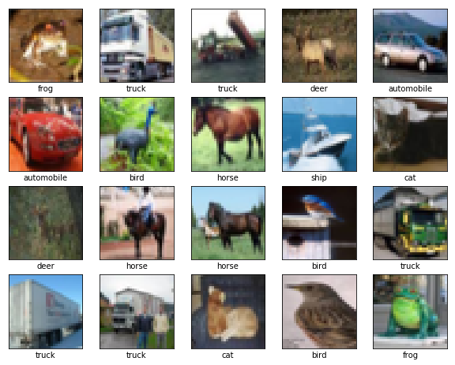

```python
class_names = ['airplane', 'automobile', 'bird', 'cat', 'deer',
               'dog', 'frog', 'horse', 'ship', 'truck']

plt.figure(figsize=(10,10))
for i in range(20):
    plt.subplot(5,5,i+1)
    plt.xticks([])
    plt.yticks([])
    plt.grid(False)
    plt.imshow(train_images[i], cmap=plt.cm.binary)
    # The CIFAR labels happen to be arrays,
    # which is why you need the extra index
    plt.xlabel(class_names[train_labels[i][0]])
plt.show()
```

### Convolutional layers

The following code defines the convolutional stack of `Conv2D` and `MaxPooling2D` layers.

A CNN takes an input of shape (`image_height`, `image_width`, `color_channels`). In this example, we will configure a CNN to process inputs of shape (32, 32, 3), which is the format of CIFAR images:

```python
model = models.Sequential()
model.add(layers.Conv2D(32, (3, 3), activation='relu', input_shape=(32, 32, 3)))
model.add(layers.MaxPooling2D((2, 2)))
model.add(layers.Conv2D(64, (3, 3), activation='relu'))
model.add(layers.MaxPooling2D((2, 2)))
model.add(layers.Conv2D(64, (3, 3), activation='relu'))
model.summary()
```

```
Model: "sequential_1"
_________________________________________________________________
Layer (type)                 Output Shape              Param #
=================================================================
conv2d_3 (Conv2D)            (None, 30, 30, 32)        896
_________________________________________________________________
max_pooling2d_2 (MaxPooling2 (None, 15, 15, 32)        0
_________________________________________________________________
conv2d_4 (Conv2D)            (None, 13, 13, 64)        18496
_________________________________________________________________
max_pooling2d_3 (MaxPooling2 (None, 6, 6, 64)          0
_________________________________________________________________
conv2d_5 (Conv2D)            (None, 4, 4, 64)          36928
=================================================================
Total params: 56,320
Trainable params: 56,320
Non-trainable params: 0
_________________________________________________________________
```

### Adding Dense layers

```python
model.add(layers.Flatten())
model.add(layers.Dense(64, activation='relu'))
model.add(layers.Dense(10))

model.summary()
```

[output not shown]

Let's now train the model:

```python
model.compile(optimizer='adam',
              loss=tf.keras.losses.SparseCategoricalCrossentropy(from_logits=True),
              metrics=['accuracy'])

history = model.fit(train_images, train_labels, epochs=10,
                    validation_data=(test_images, test_labels))
```

```
Train on 50000 samples, validate on 10000 samples
```

We can evaluate the model now on the test set:

```
10000/10000 - 5s - loss: 1.1732 - acc: 0.6961
```

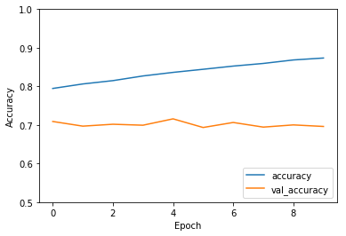

```python
import matplotlib.pyplot as plt

plt.plot(history.history['acc'], label='accuracy')
plt.plot(history.history['val_acc'], label = 'val_accuracy')
plt.xlabel('Epoch')
plt.ylabel('Accuracy')
plt.ylim([0.5, 1])
plt.legend(loc='lower right')

test_loss, test_acc = model.evaluate(test_images,  test_labels, verbose=2)
```

```python
print(test_acc)
```

```
0.6961
```